# Como Criar Extensões para o Jupyter Notebook

[João Felipe Nicolaci Pimentel](http://joao.npimentel.net/)  
joaofelipenp@gmail.com  
https://github.com/JoaoFelipe/presentations/20160820_PythonRio_Niteroi

## Jupyter Notebook

- Aplicação Web
- Permite criar e compartilhar documentos

```python
%%javascript
element.text(IPython.notebook.notebook_path)
```

- Texto, equações (markdown + latex)

$$a = 16; b = 32; c = 22$$$$\sqrt{a^2 + b^2 + c^2}$$

- Código

```python
a, b, c = 16, 32, 22
(a ** 2 + b ** 2 + c ** 2) ** 0.5
```

```
42.0
```

- Visualizações

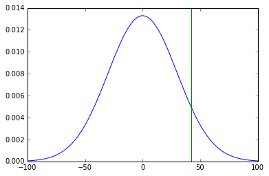

```python
%matplotlib inline
import matplotlib.pyplot as plt
import matplotlib.mlab as mlab
import numpy as np

x = np.linspace(-100, 100, 100)
plt.plot(x, mlab.normpdf(x, 0, 30))
plt.plot([_, _], [0, .014])
```

## IPython

- Kernel para Jupyter Notebook
- [Superset de Python](http://ipython.readthedocs.io/en/stable/interactive/python-ipython-diff.html)

```python
comando = "--version"
!python {comando}
```

```
Python 3.5.2 :: Anaconda 4.0.0 (64-bit)
```

```python
variaveis = %who_ls
for var, _ in zip(variaveis, range(3)):
    print(var, eval(var))
```

```
a 16
b 32
c 22
```

```python
%who_ls?
```

- Autocompletar

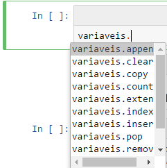

```python
from IPython.display import Image
Image("autocompletar.png")
```

## Mais Interações!

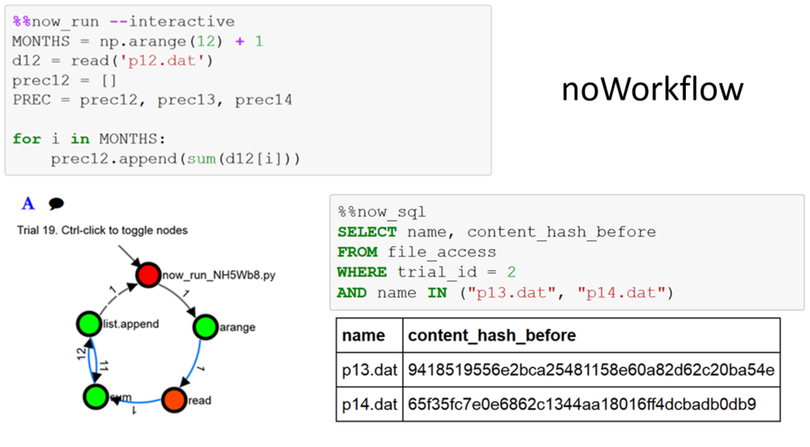

```python
from IPython.display import Image
Image("noworkflow.png")
```

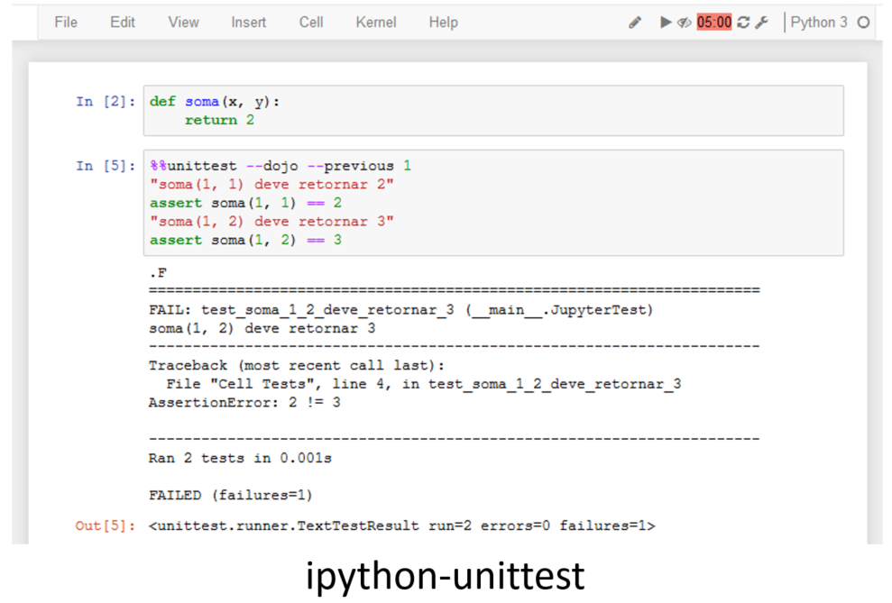

```python
from IPython.display import Image
Image("ipythonunittest.png")
```

## Extensões

- [Integração de Objetos com IPython](http://ipython.readthedocs.io/en/stable/config/integrating.html)
- [Extensão IPython](http://ipython.readthedocs.io/en/stable/config/extensions/index.html)
- [nbextension](http://jupyter-notebook.readthedocs.io/en/latest/extending/frontend_extensions.html)
  - Também chamada de extensão front-end
- [Extensão de servidor](http://jupyter-notebook.readthedocs.io/en/latest/extending/handlers.html#writing-a-notebook-server-extension)
  - Novas rotas. Novos tratamentos de requisição. Hooks na hora de salvar
- [Extensão bundler](http://jupyter-notebook.readthedocs.io/en/latest/extending/bundler_extensions.html)
  - Download as
  - Deploy

## Integração de Objetos com IPython

- Visualização
  - svg, png, jpg, html, javascript, latex
- Opções de Autocompletar
- Traceback de exceções

### Visualização

- Defina um método `_repr_*_(self)`
  - svg, png, jpg, html, javascript, latex

```python
class Raiz:
    def __init__(self, numero):
        self.numero = numero

    def _repr_latex_(self):
        return "$$\sqrt{{{}}}$$".format(self.numero)

Raiz(25)
```

$$\sqrt{25}$$

```python
import os
from subprocess import Popen, PIPE as P

class Grafo:
    def __init__(self, adjacentes):
        self.adjacentes = adjacentes

    def dottext(self):
        result = [
            "  {} -> {};".format(no, adjacente)
            for no, lista in self.adjacentes.items()
            for adjacente in lista
        ]
        return "digraph G {{\n  ranksep=0.25;\n{}\n}}".format("\n".join(result))

    def dot(self, format="png"):  # ToDo: Tratar erro
        kwargs = {} if os.name != 'nt' else {"creationflags": 0x08000000}
        p = Popen(['dot', '-T', format], stdout=P, stdin=P, stderr=P, **kwargs)
        return p.communicate(self.dottext().encode('utf-8'))[0]

    def __repr__(self):
        return self.dottext()

    def _repr_svg_(self):
        return self.dot("svg").decode("utf-8")

    def _repr_png_(self):
        return self.dot("png")

grafo = Grafo({"a": ["b", "c"], "b": ["d"], "c": ["d"]})
```

```python
grafo
```

[figure not shown]

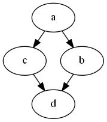

```python
from IPython.display import display_png
display_png(grafo)
```

```python
from IPython.display import display_pretty
display_pretty(grafo)
```

```
digraph G {
  ranksep=0.25;
  c -> d;
  a -> b;
  a -> c;
  b -> d;
}
```

### Autocompletar

- IPython usa a função `dir`: sobrescreva `__dir__`

```python
from string import ascii_letters

class Alfabeto:
    def __getattr__(self, letter):
        return ord(letter.lower()) - ord('a') + 1

    def __dir__(self):
        return list(ascii_letters)

alfabeto = Alfabeto()
```

```python
alfabeto.J
```

```
10
```

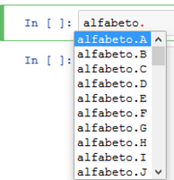

```python
from IPython.display import Image
Image("autocompletar2.png")
```

## Extensão IPython

- Funcionam como módulos
- Funcionalidades específicas do IPython
  - Magics (Line, Cell)
  - Callbacks

### Extensão IPython - Módulos

```python
%%writefile minhaext.py
def load_ipython_extension(ipython):
    print("Carregou")

def unload_ipython_extension(ipython):
    print("Descarregou")
```

```
Writing minhaext.py
```

```python
%load_ext minhaext
```

```
Carregou
```

```python
%reload_ext minhaext
```

```
Descarregou
Carregou
```

```python
%unload_ext minhaext
```

```
Descarregou
```

- Módulos também podem ser instalados em ~/.ipython/extensions/

```python
import os
os.listdir(os.path.expanduser(os.path.join("~", ".ipython", "extensions")))
```

```
['__pycache__']
```

```python
%install_ext minhaext.py
import os
os.remove("minhaext.py")
```

```
Installed minhaext.py. To use it, type:
  %load_ext minhaext
```

```python
import os
os.listdir(os.path.expanduser(os.path.join("~", ".ipython", "extensions")))
```

```
['minhaext.py', '__pycache__']
```

```python
%load_ext minhaext
```

```
Carregou
```

- Para evitar `%load_ext`, liste as extensões que serão carregadas no arquivo de configuração

```python
!ipython profile create
```

```
[ProfileCreate] Generating default config file: 'C:\\Users\\joao\\.ipython\\profile_default\\ipython_config.py'
```

```python
%%writefile -a {os.path.expanduser(os.path.join("~", ".ipython", "profile_default", "ipython_config.py"))}
c.InteractiveShellApp.extensions = [
    'minhaext',
]
```

```
Appending to C:\Users\joao\.ipython\profile_default\ipython_config.py
```

```python
%unload_ext minhaext
```

```
Descarregou
```

```python
%%javascript
// Reiniciando Kernel
// [*] não vai sumir
IPython.notebook.kernel.restart()
```

```python
%load_ext minhaext
```

```
The minhaext extension is already loaded. To reload it, use:
  %reload_ext minhaext
```

```python
%unload_ext minhaext
import os
os.remove(os.path.expanduser(os.path.join("~", ".ipython", "profile_default", "ipython_config.py")))
os.remove(os.path.expanduser(os.path.join("~", ".ipython", "extensions", "minhaext.py")))
```

```
Descarregou
```

- É melhor criar pacotes Python

```python
import os
projects_dir, extension_name = ".", "ipythonext"
os.makedirs(os.path.join(projects_dir, extension_name, extension_name))
```

```python
%%writefile {projects_dir}/{extension_name}/setup.py
from setuptools import setup, find_packages
setup(
    name="IPython Extension",
    version="1.0",
    description="How to create IPython Extensions",
    author="JF",
    author_email="joaofelipenp@gmail.com",
    packages=find_packages(),
)
```

```
Writing ./ipythonext/setup.py
```

```python
%%writefile {projects_dir}/{extension_name}/{extension_name}/__init__.py
def load_ipython_extension(ipython):
    print("Carregou")
```

```
Writing ./ipythonext/ipythonext/__init__.py
```

```python
!pip install -e {projects_dir}/{extension_name}
```

```
Obtaining file:///C:/Users/joao/jupyter/ipythonext
  Running setup.py develop for IPython-Extension
```

```python
%%javascript
// Reiniciando Kernel
// [*] não vai sumir
IPython.notebook.kernel.restart()
```

```python
%load_ext ipythonext
```

```
Carregou
```

### O que fazer com extensões

```
def load_ipython_extension(ipython: "InteractiveShell"):
```

- Registrar Magics
- Registrar Callbacks

```python
ipython = get_ipython()
```

#### Registrando Magics

```python
def ospath(line):
    from os import path
    return getattr(path, line) if line else path

ipython.register_magic_function(ospath, magic_kind='line')
```

```python
# from os.path import join
funcao = "join"
join = %ospath {funcao}
join("a", "b")
```

```
'a\\b'
```

```python
from IPython.core.magic import Magics, magics_class, line_magic, cell_magic, line_cell_magic
from IPython.core.magic_arguments import argument, magic_arguments, parse_argstring
from IPython.display import Javascript, display

@magics_class
class Magicas(Magics):
    @line_cell_magic
    def decorar(self, line, cell=None):
        decorador = line.split(" ")[0]
        if cell is None:
            funcao = line.split(" ")[-1]
            self.shell.user_ns[funcao] = self.shell.user_ns[decorador](self.shell.user_ns[funcao])
        else:
            tree = ast.parse(cell)
            tree = TransformarDefinicoes(decorador).visit(tree)
            compiled = compile(tree, 'Cell Tests', 'exec')
            exec(compiled, self.shell.user_global_ns, self.shell.user_ns)

    @magic_arguments()
    @argument('-b', '--backward', default=-1, type=int, help="set cursor to P cells before")
    @argument('-f', '--forward', default=-1, type=int, help="set cursor to P cells after")
    @line_magic
    def move(self, line):
        args = parse_argstring(self.move, line)
        if args.forward != -1:
            args.backward = -args.forward
        if args.backward != -1:
            display(Javascript(
                "Jupyter.notebook.select("
                "Jupyter.notebook.get_selected_index() - {})"
                .format(args.backward + 1)
            ))
```

```python
import ast
class TransformarDefinicoes(ast.NodeTransformer):
    def __init__(self, decorador):
        self.decorador = decorador
    def visit_FunctionDef(self, node):
        node.decorator_list.append(ast.copy_location(ast.Name(self.decorador, ast.Load()), node))
        return node


ipython.register_magics(Magicas)
```

```python
from functools import wraps
def imprimir_chamadas(f):
    @wraps(f)
    def dec(*args, **kwargs):
        result = f(*args, **kwargs)
        print("{}(*{}, **{}) = {}".format(f.__name__, args, kwargs, result))
        return result
    return dec
```

```python
%%decorar imprimir_chamadas
def soma(x, y):
    return x + y
```

```python
soma(1, 2)
```

```
soma(*(1, 2), **{}) = 3
```

```
3
```

```python
def subtracao(x, y):
    return x - y
%decorar imprimir_chamadas subtracao
subtracao(1, 2)
```

```
subtracao(*(1, 2), **{}) = -1
```

```
-1
```

```python
%move -b 1
```

#### Registrando callbacks

```python
from time import clock
class Timer:
    def __init__(self):
        self.initial = 0
    def pre_execute(self):
        self.initial = clock()
    def post_execute(self):
        print(clock() - self.initial)
timer = Timer()
timer.pre_execute()
ipython.events.register("pre_execute", timer.pre_execute)
ipython.events.register("post_execute", timer.post_execute)
```

```
0.00012187617466181498
```

```python
from time import sleep
sleep(0.5)
```

```
0.5009936115502693
```

```python
%%javascript
// Reiniciando Kernel
// [*] não vai sumir
IPython.notebook.kernel.restart()
```

```python
# Bonus: IPython Magic semelhante a writefile que aceita substituições em Cell

def template(line, cell):
    ipython = get_ipython()
    return ipython.run_cell_magic("writefile", line, cell.format(**ipython.user_ns))

get_ipython().register_magic_function(template, magic_kind="cell")
```

## Extensão Front-end (nbextension)

- Distribuídas como módulos Python (PyPI)
- Porém possuem apenas Javascript, CSS e HTML para o notebook

```python
import os
projects_dir, extension_name = ".", "nbext"
os.makedirs(os.path.join(projects_dir, extension_name, extension_name, "static"))
```

```python
%%template {projects_dir}/{extension_name}/setup.py
import os
from setuptools import setup, find_packages
setup(
    name="Jupyter Notebook Extension",
    version="1.0",
    description="How to create Jupyter Extensions",
    author="JF",
    author_email="joaofelipenp@gmail.com",
    packages=find_packages(),
    package_data={{"{extension_name}": [os.path.join("static", "index.js")]}}
)
```

```
Writing ./nbext/setup.py
```

```python
%%template {projects_dir}/{extension_name}/{extension_name}/__init__.py
def _jupyter_nbextension_paths():
    return [dict(
        section="notebook",
        src="static",
        dest="{extension_name}",
        require="{extension_name}/index"
    )]
```

```
Writing ./nbext/nbext/__init__.py
```

```python
%%template {projects_dir}/{extension_name}/{extension_name}/static/index.js
define([
    'base/js/namespace'
], function(
    Jupyter
) {{
    function load_ipython_extension() {{
        var handler = function () {{
            var fn = prompt("Nome da função?");
            Jupyter.notebook.insert_cell_below().set_text("%%unittest -p 1 -d\nassert "+fn+"() == 0");
            Jupyter.notebook.insert_cell_below().set_text("def "+fn+"():\n    pass");
            Jupyter.notebook.insert_cell_below().set_text("%load_ext ipython_unittest");
        }};

        var action = {{
            icon: 'fa-group', // a font-awesome class used on buttons, etc
            help    : 'Iniciar dojo',
            help_index : 'zz',
            handler : handler
        }};
        var prefix = '{extension_name}';
        var action_name = 'start-dojo';

        var full_action_name = Jupyter.actions.register(action, name, prefix);
        Jupyter.toolbar.add_buttons_group([full_action_name]);
    }}
    return {{
        load_ipython_extension: load_ipython_extension
    }};
}});
```

```
Writing ./nbext/nbext/static/index.js
```

```python
!pip install -e {projects_dir}/{extension_name}
```

```
Obtaining file:///C:/Users/joao/jupyter/nbext
  Running setup.py develop for Jupyter-Notebook-Extension
```

```python
#--symlink
!jupyter nbextension install --py {extension_name} --user
```

```
Installing c:\users\joao\jupyter\nbext\nbext\static -> nbext
Out of date: C:\Users\joao\AppData\Roaming\jupyter\nbextensions\nbext\index.js
Copying: c:\users\joao\jupyter\nbext\nbext\static\index.js -> C:\Users\joao\AppData\Roaming\jupyter\nbextensions\nbext\index.js
- Validating: ok

    To initialize this nbextension in the browser every time the notebook (or other app) loads:

          jupyter nbextension enable nbext --user --py
```

```python
!jupyter nbextension enable {extension_name} --user --py
```

```
Enabling notebook extension nbext/index...
      - Validating: ok
```

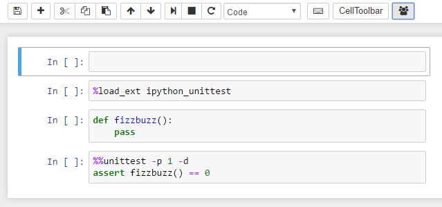

```python
from IPython.display import Image
Image("nbextension.png")
```

# Como Criar Extensões para o Jupyter Notebook

[João Felipe Nicolaci Pimentel](http://joao.npimentel.net/)  
joaofelipenp@gmail.com  
https://github.com/JoaoFelipe/presentations/20160820_PythonRio_Niteroi